# R markdown Coding Challenge

Sinka Khadijah Abubakar

2026-02-20

### Question 1

1. A YAML header is the section at the very top of an R Markdown document, enclosed by —. It contains metadata and configuration settings for the R markdown document, such as the title, author, date, and output format (e.g., HTML, PDF, or Word). It also controls how the document is rendered when you knit it.
2. Literate programming is a style of writing code where you combine explanatory text and code in the same document. Instead of just showing code, you explain what the code is doing and why.

### Question 2

**a. Clickable link to manuscript where data is published**

- Noel, Z.A., Roze, L.V., Breunig, M., Trail, F. 2022. Endophytic fungi as promising biocontrol agent to protect wheat from *Fusarium graminearum* head blight. Plant Disease.https://doi.org/10.1094/PDIS-06-21-1253-RE

**b. Read the data using a relative file path**

```r
mycotoxin <- read.csv("MycotoxinData.csv", na.strings = "na")
```

**c. Last question of coding challenge 3**

Before working with the data, we load the packages needed for plotting and figure arrangement.

```r
library(ggplot2)
library(ggpubr)
```

Define a colorblind-friendly palette

```r
cbbPalette <- c("#000000", "#E69F00", "#56B4E9", "#009E73",
                "#F0E442", "#0072B2", "#D55E00", "#CC79A7")
```

Creating a boxplot of DON by Treatment

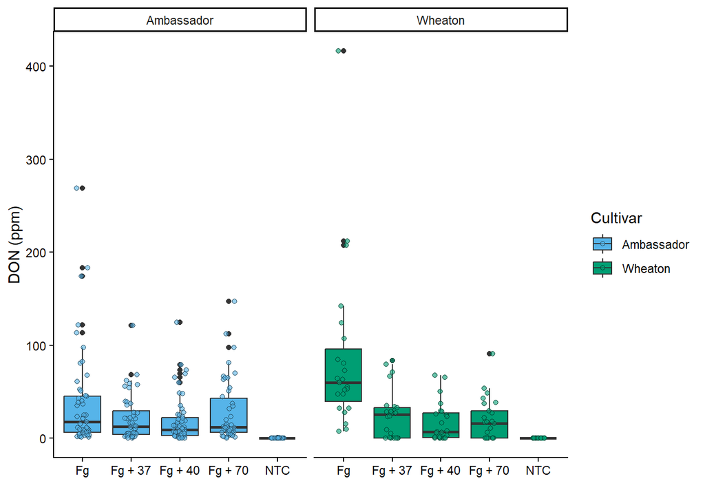

```r
plotA = ggplot(mycotoxin, aes(x = Treatment, y = DON, fill = Cultivar)) +
  geom_boxplot(position = position_dodge()) +
  geom_point(aes(fill = Cultivar), shape = 21, position = position_jitterdodge(dodge.width = 0.9), alpha = 0.6, color = "black") +     # Jittering points, changing transparency of points to 0.6
  scale_fill_manual(values = c(cbbPalette[[3]], cbbPalette[[4]])) +
  facet_wrap(~Cultivar) +    # faceting cultivar
  xlab("") +
  ylab("DON (ppm)") +    # labeling y-axis
  theme_classic()       # adding theme classic
plotA
```

Changing the factor order level so that the treatment “NTC” is first, followed by “Fg”, “Fg + 37”, “Fg + 40”, and “Fg + 70.

```r
mycotoxin$Treatment <- factor(mycotoxin$Treatment,
                              levels = c("NTC", "Fg", "Fg + 37", "Fg + 40", "Fg + 70"))
```

creating a boxplot of X15ADON by Treatment

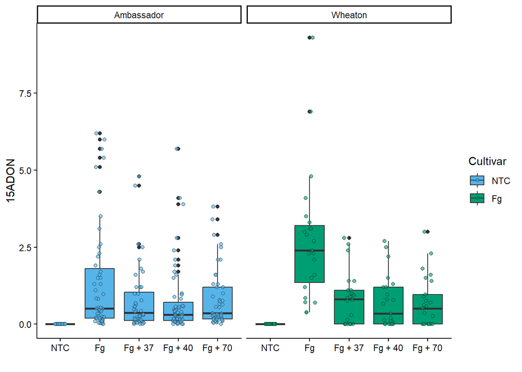

```r
plotB = ggplot(mycotoxin, aes(x = Treatment, y = X15ADON, fill = Cultivar)) +
  geom_boxplot(position = position_dodge()) +
  geom_point(aes(fill = Cultivar), shape = 21, position = position_jitterdodge(dodge.width = 0.9), alpha = 0.6, color = "black") +     # Jittering points, changing transparency of points to 0.6
  scale_fill_manual(values = c(cbbPalette[[3]], cbbPalette[[4]]), labels = c("NTC", "Fg", "Fg + 37", "Fg + 40", "Fg + 70")) +
  facet_wrap(~Cultivar) +    # faceting cultivar
  xlab("") +
  ylab("15ADON") +    # labeling y-axis
  theme_classic()
plotB
```

Creating a boxplot of MassperSeed_mg by Treatment

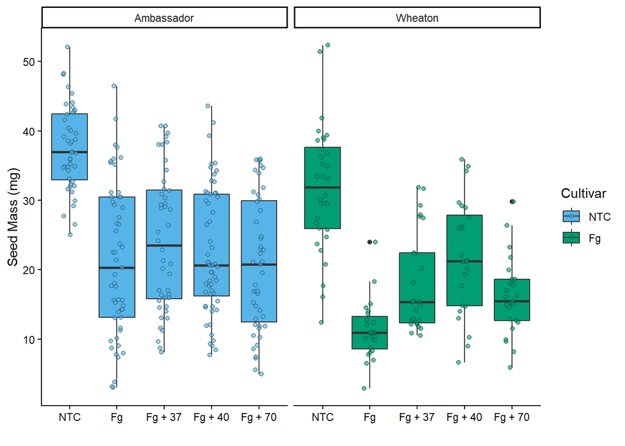

```r
plotC = ggplot(mycotoxin, aes(x = Treatment, y = MassperSeed_mg, fill = Cultivar)) +
  geom_boxplot(position = position_dodge()) +
  geom_point(aes(fill = Cultivar), shape = 21, position = position_jitterdodge(dodge.width = 0.9), alpha = 0.6, color = "black") +     # Jittering points, changing transparency of points to 0.6
  scale_fill_manual(values = c(cbbPalette[[3]], cbbPalette[[4]]), labels = c("NTC", "Fg", "Fg + 37", "Fg + 40", "Fg + 70")) +
  facet_wrap(~Cultivar) +    # faceting cultivar
  xlab("") +
  ylab("Seed Mass (mg)") +    # labeling y-axis
  theme_classic()
plotC
```

Using geom_pwc() to add t.test pairwise comparisons to the three plots made above. Saving each plot as a new R object, and combine them with *ggarange* function

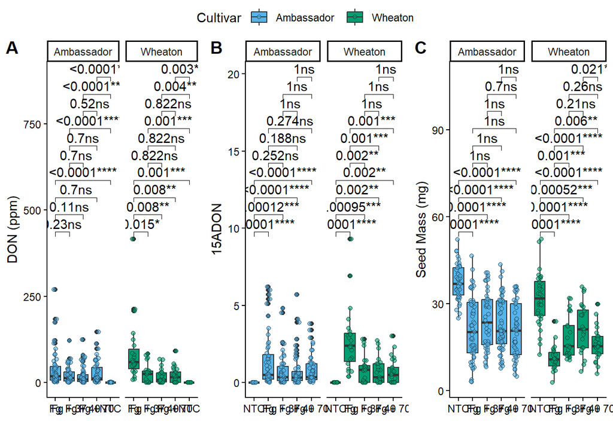

```r
plotD <- plotA +
  geom_pwc(aes(group = Treatment), method = "t_test", label = "{p.adj.format}{p.adj.signif}")

plotE <- plotB +
  geom_pwc(aes(group = Treatment), method = "t_test", label = "{p.adj.format}{p.adj.signif}")

plotF <- plotC +
  geom_pwc(aes(group = Treatment), method = "t_test", label = "{p.adj.format}{p.adj.signif}")

figure <- ggarrange(
  plotD,  # First plot (pwc_DON by Treatment)
  plotE,  # Second plot (pwc_X15ADON by Treatment)
  plotF,  # Third plot (pwc_MassperSeed_mg by Treatment)
  labels = c("A", "B", "C"),  # label the plots (A, B, C)
  nrow = 1,  # Arrange the plots in 3 rows
  ncol = 3,  # Arrange the plots in 1 column
  common.legend = TRUE  # Including a legend in the combined figure
)
figure
```